# Distribuciones multivariadas

Módulo 2

David R. Montalván Hernández

# **Distribuciones multivariadas**

## **Función de distribución bivariada**

La función de distribución de dos variables $X,Y$ es la función $F_{XY}(x,y)$ tal que

$$F_{XY}(x,y) = \mathbb{P}(X \leq x , Y \leq y)$$

en donde $(X \leq x , Y \leq y)=(X \leq x \cap Y \leq y)$.

## **Propiedades de $F_{XY}$**

- $0 \leq F_{XY}(x,y) \leq 1$.
- Si $x_1 \leq x_2$ y $y_1 \leq y_2$, entonces

$$\begin{array}
FF_{XY}(x_1, y_1) & \leq & F(x_2, y_1) & \leq & F_{XY}(x_2, y_2)\\
F_{XY}(x_1, y_1) & \leq & F(x_1, y_2) & \leq & F_{XY}(x_2, y_2)
\end{array}$$

- $\lim_{x,y \rightarrow \infty} F_{XY}(x,y) = 1$
- $\lim_{x \rightarrow -\infty} F_{XY}(x,y) = \lim_{y \rightarrow -\infty} F_{XY}(x,y) = 0$
- $\mathbb{P}(x_1 < X \leq x_2, Y \leq y) = F_{XY}(x_2, y) - F_{XY}(x_1, y)$
- $\mathbb{P}(X \leq x,y_1 < Y \leq y_2) = F_{XY}(x, y_2) - F_{XY}(x, y_1)$
- Si $x_1 \leq x_2$ y $y_1 \leq y_2$, entonces

$$\begin{array}
\mathbb{P}(x_1 < X \leq x_2, y_1 < Y \leq y_2) & = & F_{XY}(x_2, y_2) \\
& + & F_{XY}(x_1, y_1) \\
& - & F_{XY}(x_1, y_2) \\
& - & F_{XY}(x_2, y_1)
\end{array}$$

## **Distribución marginal**

Las distribuciones marginales están dadas por

$$\lim_{y \rightarrow \infty} F_{XY}(x, y) = F_{X}(x)$$

$$\lim_{x \rightarrow \infty} F_{XY}(x, y) = F_{Y}(y)$$

## **Densidad bivariada conjunta (discreto)**

Sea $(X, Y)$ un par de variables aleatorias discretas que toman los valores $(x_i, y_j)_{i,j=1,2,\ldots}$ y definidas sobre un mismo espacio muestral $\Omega$. La función de densidad conjunta, $p$, se define como

$$p(x_i, y_j) = \mathbb{P}\left(X = x_i, Y = y_j \right)$$

## **Propiedades**

La función de densidad conjunta cumple lo siguiente

- $0 \leq p_{XY}(x_i, y_j) \leq 1$
- $\sum_{x_i} \sum_{y_j} p_{XY}(x_i,y_j) = 1$
- $\mathbb{P}\left[ \left(X,Y \right) \in A \right] = \sum_{(x_i, y_j) \in A} p_{XY}(x_i, y_j)$

## **Densidades marginales (discreto)**

Para obtener la densidad marginal de una variable, basta sumar sobre todos los valores de la otra variable, así:

$$\mathbb{P}(X = x_i) = \sum_{y_j}p_{XY}(x_i, y_j)$$
$$\mathbb{P}(Y = y_j) = \sum_{x_i}p_{XY}(x_i, y_j)$$

## **Densidad bivariada conjunta (continuo)**

Si $(X,Y)$ son variables continuas con función de distribución $F_{XY}(x,y)$, la función de densidad conjunta está dada por

$$f_{XY}(x, y) = \dfrac{\partial^2 F_{XY}(x,y)}{\partial x \partial y}$$

integrando lo anterior, podemos ver que

$$F_{XY}(x_0,y_0) = \int_{-\infty}^{x_0} \int_{-\infty}^{y_0} f_{XY}(x,y)dx dy$$

## **Propiedades de $f_{XY}$**

- $f_{XY}(x,y) \geq 0$.
- $\int_{-\infty}^{\infty} \int_{-\infty}^{\infty} f_{XY}(x,y) dx dy = 1$
- $f_{XY}(x,y)$ es continua excepto posiblemente en conjuntos de medida cero ($\mathbb{Q}, \mathbb{Z}, \mathbb{N}$)
- $\mathbb{P}\left[ (X, Y) \in A \right] = \int \int \mathbb{I}_{A} f_{XY}(x,y)dxdy$
- $\mathbb{P}(a < X \leq b, c < Y \leq d) = \int_{c}^{d} \int_{a}^{b} f_{XY}(x, y)dxdy$

## **Densidades marginales (continuo)**

$$F_{X}(x_0) = \int_{-\infty}^{x_0}\int_{-\infty}^{\infty}f_{XY}(x,y)dydx \\
f_{X}(x_0) = \dfrac{d F_{X}(x_0)}{dx_0} = \int_{-\infty}^{\infty} f_{XY}(x_0, y)dy$$

Similar para $F_{Y}$ y $f_{Y}$.

## **Independencia de variables aleatorias**

Sean $X_1, \ldots, X_n$ variables aleatorias, decimos que son independientes si

$$F(x_1, \ldots, x_n) = \Pi_{i=1}^{n} F_{X_i}(x_i)$$

equivalente a

$$f(x_1, \ldots, x_n) = \Pi_{i=1}^{n} f_{X_i}(x_i)$$

Y por lo tanto $E[\Pi_{i = 1}^{n} X_i] = \Pi_{i=1}^{n}E[X_i]$

## **Densidades condicionales**

La función de densidad condicional de $X$ dado $Y$, está dada por

$$f_{X|Y}(x|y) = \dfrac{f_{XY}(x,y) }{f_{Y}(y)} \, \text{ con } \, f_{Y}(y) > 0$$

similar para $Y|X$.

Esta función cumple lo siguiente

- $f_{X|Y}(x|y) \geq 0$
- $\int_{-\infty}^{\infty}f_{X|Y}(x|y)dx = 1$

## **Ejercicio**

Demuestre lo siguiente

$$\begin{matrix}
f(x_1, x_2 | x_3, x_4) & = & \dfrac{f(x_1, x_2, x_3 | x_4)}{f(x_3 | x_4)} \\
f(x_1, x_2 | x_3, x_4) & = & f(x_1 | x_2, x_3, x_4) f(x_2 | x_3, x_4)
\end{matrix}$$

## **Ejercicio**

Suponga que se tiran dos dados de $3$ caras. Sea $X$ la cara que muestra el primer dado y sea $Y$ la suma de los dos dados. Utilizando simulación encuentre $f_{XY}$ y a partir de esta densidad, encuentre las densidades marginales $f_{X}$ y $f_{Y}$.

Utilice $100,000$ simulaciones.

```python
import numpy as np
help(np.random.choice)
help(np.logical_and)
```

## **Esperanza condicional**

La esperanza condicional de $Y$ dado $X = x$ se define como

$$\begin{array}
EE[Y | X = x] & = & \sum_{y \in \Omega_{Y}} y f_{Y|X}(y | x) \, \text { caso discreto} \\
& = & \int_{\Omega_{Y}} y f_{Y|X}(y | x)dy \, \text { caso continuo}
\end{array}$$

**Nota:**

La esperanza condicional de $Y$ dado $X$, es una función de $X$.

## **Varianza condicional**

La varianza condicional de $Y$ dado $X=x$ está dada por:

$$Var(Y|X=x) = E\left[ \left(Y - E[Y | X = x] \right)^2 | X=x \right]$$

Es posible demostrar que $Var(Y|X=x) = E[Y^2|X=x] - \left(E[Y|X=x] \right)^2$

## **Método de la transformada inversa**

Si una variable aleatoria $X$ tiene función de distribución $F$, es posible simular valores de $X$ utilizando el método de la transformada inversa.

1. Obtener $F^{-1}$
2. Simular una variable uniforme, $U$, en el intervalo $(0,1)$
3. El número $F^{-1}(U)$ tendra la misma distribución que $X$

En el caso continuo $F^{-1}$ es la función inversa de $F$, en el caso discreto $F^{-1}(u) = \min \{x: F(x) \geq u\}$

## **Ejercicio**

Si $f(x,y) = 6(1 - y)$ para $0 < x < y < 1$, utilizando simulación compruebe que

- $E\left[X | Y = 1 /2 \right] = 0.25$
- $Var\left[X | Y = 1 /2 \right] = 0.021$

Utilice $100,000$ simulaciones.

```python
import numpy as np
help(np.random.uniform)
```

# **Covarianza y correlación**

## **Covarianza**

Sean $X,Y$ dos variables aleatorias con esperanza finita, la covarianza de $X$ y $Y$ está dada por

$$Cov(X,Y) = E[(X - \mu_{X})(Y - \mu_{Y})]$$

Esta cantidad buscar medir el grado relación lineal que tienen las variables.

## **Correlación**

Ya que la magnitud de la covarianza depende de las unidades de $X$ y $Y$, su interpretación es difícil ¿Qué indicaría una covarianza igual a $5$?

El coeficiente de correlación busca solucionar este problema

$$\rho(X,Y) = \dfrac{ Cov(X,Y) }{ \sqrt{Var(X) Var(Y)} }.$$

Es posible demostrar que $-1\leq \rho(X,Y) \leq 1$.

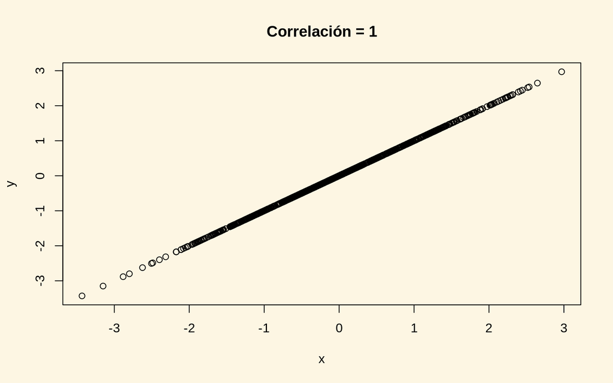

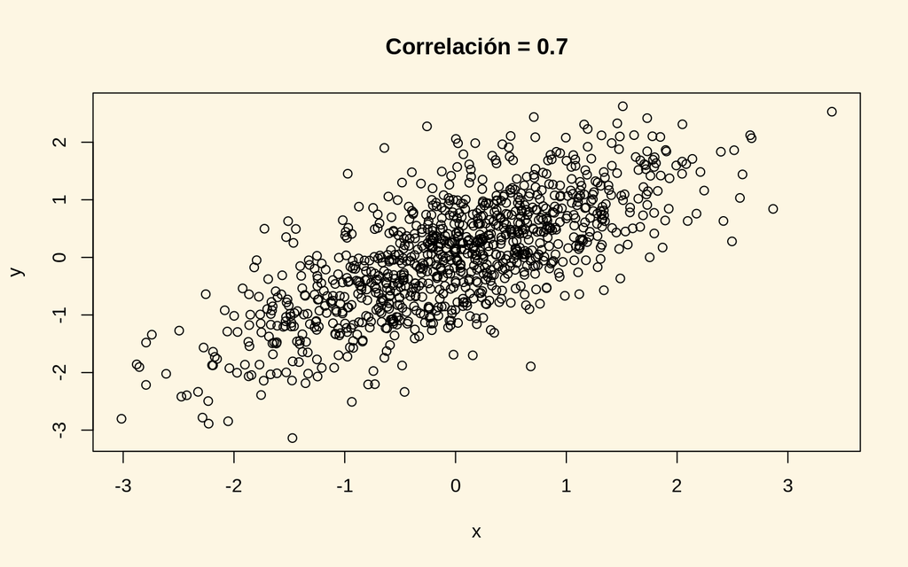

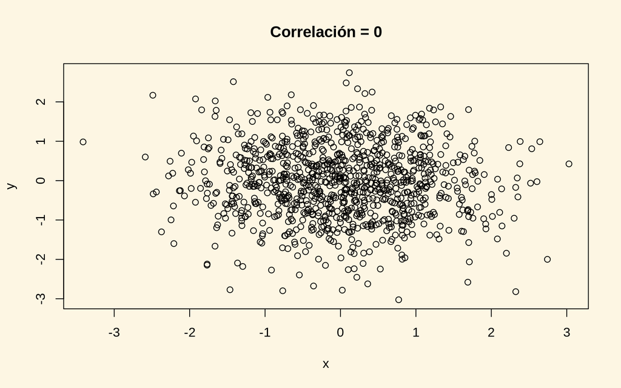

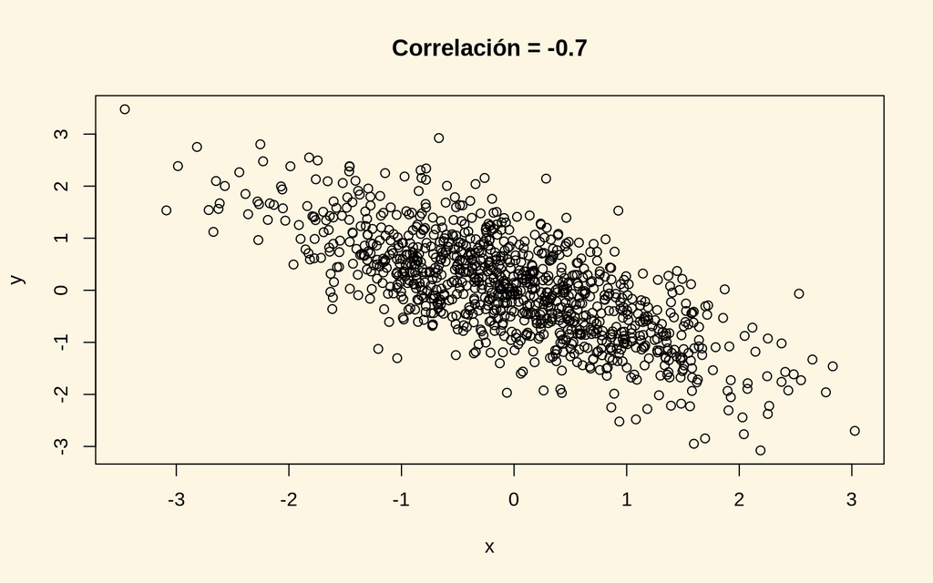

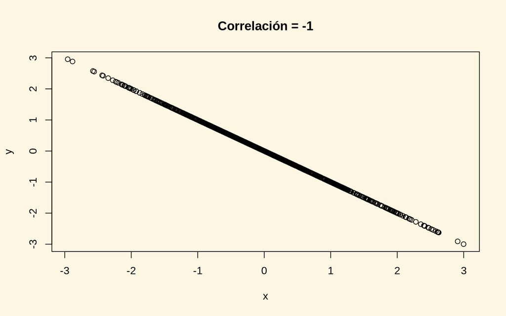

## **Propiedades de la covarianza**

- $Cov(X, constante) = 0$
- $Cov(X, X) = Var(X)$.
- $Cov(\sum_{i = 1}^{n} a_i X_i, \sum_{j = 1}^{m} b_j Y_j ) = \sum_{i=1}^{n} \sum_{j=1}^{m} a_i b_j Cov(X_i, Y_j)$.

Utilizando los últimos dos puntos, tenemos que

- $Var(aX + bY) = a^{2} Var(X) + b^{2} Var(Y) + 2ab Cov(X,Y)$

y en general

$$Var\left( \sum_{i=1}^{n} a_i X_i \right) = \sum_{i=1}^{n} a_{i}^{2} Var(X_i) + 2 \sum_{i} \sum_{j} a_{i} a_{j} Cov(X_i, X_j)$$

Finalmente, si $X$ y $Y$ son independientes, entonces $Cov(X,Y) = 0$.

## **Matriz de covarianzas**

Si tenemos un conjunto de variables (vector aleatorio) $\mathbf{X} = (X_1, X_2, \ldots, X_n)$, su matriz de varianzas y covarianzas está dada por:

$$\Sigma_{n \times n} =
\begin{pmatrix}
Var(X_1) & Cov(X_1, X_2) & \ldots & Cov(X_1, X_n)\\
Cov(X_2, X_1) & Var(X_2) & \ldots & Cov(X_2, X_n)\\
\vdots & \vdots & \ddots & \vdots \\
Cov(X_n, X_1) & \ldots & \ldots & Var(X_n)
\end{pmatrix}$$

## **Matriz de correlaciones**

Si tenemos un conjunto de variables (vector aleatorio) $\mathbf{X} = (X_1, X_2, \ldots, X_n)$, su matriz de correlaciones está dada por:

$$C_{n \times n} =
\begin{pmatrix}
1 & \rho(X_1, X_2) & \ldots & \rho(X_1, X_n)\\
\rho(X_2, X_1) & 1 & \ldots & \rho(X_2, X_n)\\
\vdots & \vdots & \ddots & \vdots \\
\rho(X_n, X_1) & \ldots & \ldots & 1
\end{pmatrix}$$

Ya que $Cov(X,Y) = Cov(Y, X)$, tenemos entonces que la matriz de covarianzas y de correlaciones son simétricas.

Con numpy, podemos utilizar la función `cov` para obtner la matriz de covarianzas y la función `corrcoef` para obtener la matriz de correlaciones.

**Nota:** En ambas funciones revise el parámetro `rowvar`.

```python
import numpy as np
import matplotlib.pyplot as plt
help(np.cov)
help(np.corrcoef)
n_muestras = int(1e5)

np.random.seed(1234)
#Variables normales media cero desviación estándar 1
x_1 = np.random.normal(size = n_muestras)

#coeficiente de correlación
rho = 0.7

#x_2 tiene correlación rho con x_1
#y tiene distribución normal media 0 desviación estándar 2
sig_2 = 2
z = np.random.normal(size = n_muestras)
x_2 = sig_2 * (rho * x_1 + np.sqrt(1 - rho**2) * z)

#matriz de datos
#en este caso cada cada renglón es una variable
#y cada columna es una observación
#Estructura default del parámetro rowvar
mat_datos = np.array([x_1, x_2])
print(mat_datos.shape)

#matriz de covarianzas
mat_cov = np.cov(mat_datos)


#matriz de correlaciones
mat_cor = np.corrcoef(mat_datos)

print('La matriz de covarianzas es')
print(mat_cov)
print('-' * 50)
print('La matriz de correlaciones es')
print(mat_cor)

plt.plot(x_1, x_2, '.')
plt.xlabel('$X_1$')
plt.ylabel('$X_2$')
plt.show()
```

[output not shown]